# 白葡萄酒质量探索 –王蜜海

在本报告中探索4898条白葡萄酒样品的11种化学成分及其质量评分。

```
## [1] 4898   12
```

```
## 'data.frame':    4898 obs. of  12 variables:
##  $ fixed.acidity       : num  7 6.3 8.1 7.2 7.2 8.1 6.2 7 6.3 8.1 ...
##  $ volatile.acidity    : num  0.27 0.3 0.28 0.23 0.23 0.28 0.32 0.27 0.3 0.22 ...
##  $ citric.acid         : num  0.36 0.34 0.4 0.32 0.32 0.4 0.16 0.36 0.34 0.43 ...
##  $ residual.sugar      : num  20.7 1.6 6.9 8.5 8.5 6.9 7 20.7 1.6 1.5 ...
##  $ chlorides           : num  0.045 0.049 0.05 0.058 0.058 0.05 0.045 0.045 0.049 0.044 ...
##  $ free.sulfur.dioxide : num  45 14 30 47 47 30 30 45 14 28 ...
##  $ total.sulfur.dioxide: num  170 132 97 186 186 97 136 170 132 129 ...
##  $ density             : num  1.001 0.994 0.995 0.996 0.996 ...
##  $ pH                  : num  3 3.3 3.26 3.19 3.19 3.26 3.18 3 3.3 3.22 ...
##  $ sulphates           : num  0.45 0.49 0.44 0.4 0.4 0.44 0.47 0.45 0.49 0.45 ...
##  $ alcohol             : num  8.8 9.5 10.1 9.9 9.9 10.1 9.6 8.8 9.5 11 ...
##  $ quality             : int  6 6 6 6 6 6 6 6 6 6 ...
```

```
##  fixed.acidity    volatile.acidity  citric.acid     residual.sugar
##  Min.   : 3.800   Min.   :0.0800   Min.   :0.0000   Min.   : 0.600
##  1st Qu.: 6.300   1st Qu.:0.2100   1st Qu.:0.2700   1st Qu.: 1.700
##  Median : 6.800   Median :0.2600   Median :0.3200   Median : 5.200
##  Mean   : 6.855   Mean   :0.2782   Mean   :0.3342   Mean   : 6.391
##  3rd Qu.: 7.300   3rd Qu.:0.3200   3rd Qu.:0.3900   3rd Qu.: 9.900
##  Max.   :14.200   Max.   :1.1000   Max.   :1.6600   Max.   :65.800
##    chlorides       free.sulfur.dioxide total.sulfur.dioxide
##  Min.   :0.00900   Min.   :  2.00      Min.   :  9.0
##  1st Qu.:0.03600   1st Qu.: 23.00      1st Qu.:108.0
##  Median :0.04300   Median : 34.00      Median :134.0
##  Mean   :0.04577   Mean   : 35.31      Mean   :138.4
##  3rd Qu.:0.05000   3rd Qu.: 46.00      3rd Qu.:167.0
##  Max.   :0.34600   Max.   :289.00      Max.   :440.0
##     density             pH          sulphates         alcohol
##  Min.   :0.9871   Min.   :2.720   Min.   :0.2200   Min.   : 8.00
##  1st Qu.:0.9917   1st Qu.:3.090   1st Qu.:0.4100   1st Qu.: 9.50
##  Median :0.9937   Median :3.180   Median :0.4700   Median :10.40
##  Mean   :0.9940   Mean   :3.188   Mean   :0.4898   Mean   :10.51
##  3rd Qu.:0.9961   3rd Qu.:3.280   3rd Qu.:0.5500   3rd Qu.:11.40
##  Max.   :1.0390   Max.   :3.820   Max.   :1.0800   Max.   :14.20
##     quality
##  Min.   :3.000
##  1st Qu.:5.000
##  Median :6.000
##  Mean   :5.878
##  3rd Qu.:6.000
##  Max.   :9.000
```

# 单变量绘图选择

下面作出各指标的分布图。

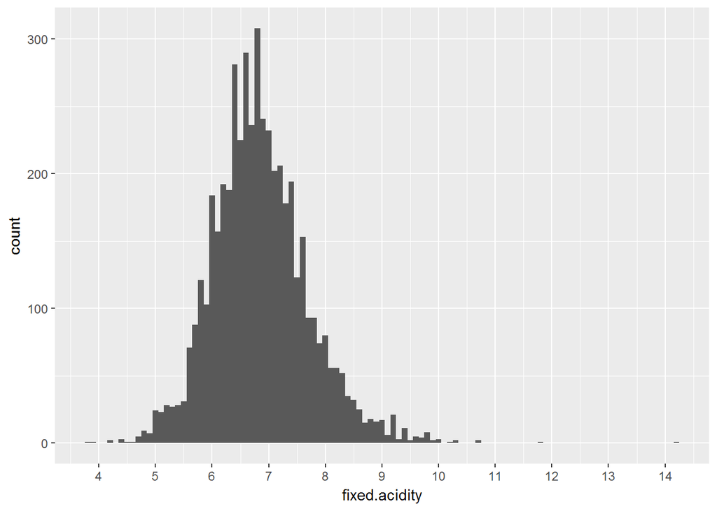

fixed.acidity呈现正态分布。

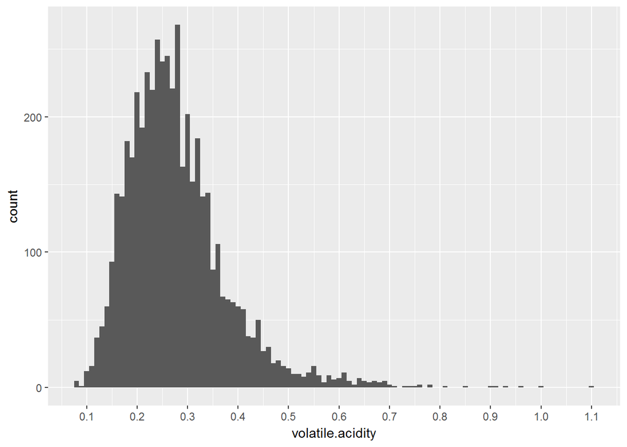

```
##    Min. 1st Qu.  Median    Mean 3rd Qu.    Max.
##  0.0800  0.2100  0.2600  0.2782  0.3200  1.1000
```

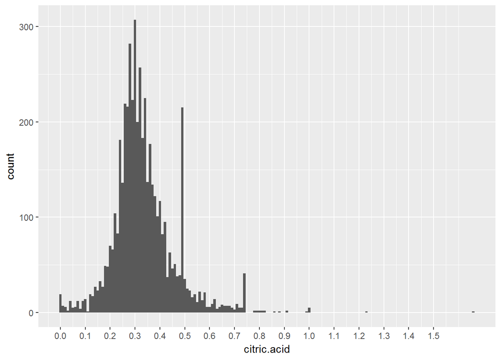

```
##    Min. 1st Qu.  Median    Mean 3rd Qu.    Max.
##  0.0000  0.2700  0.3200  0.3342  0.3900  1.6600
```

volatile.acidity和citric.acid浓度要比fixed.acidity小一个量级。可能因此对quality的影响要小一些。也大致是正态分布。

作residual.sugar的分布图：

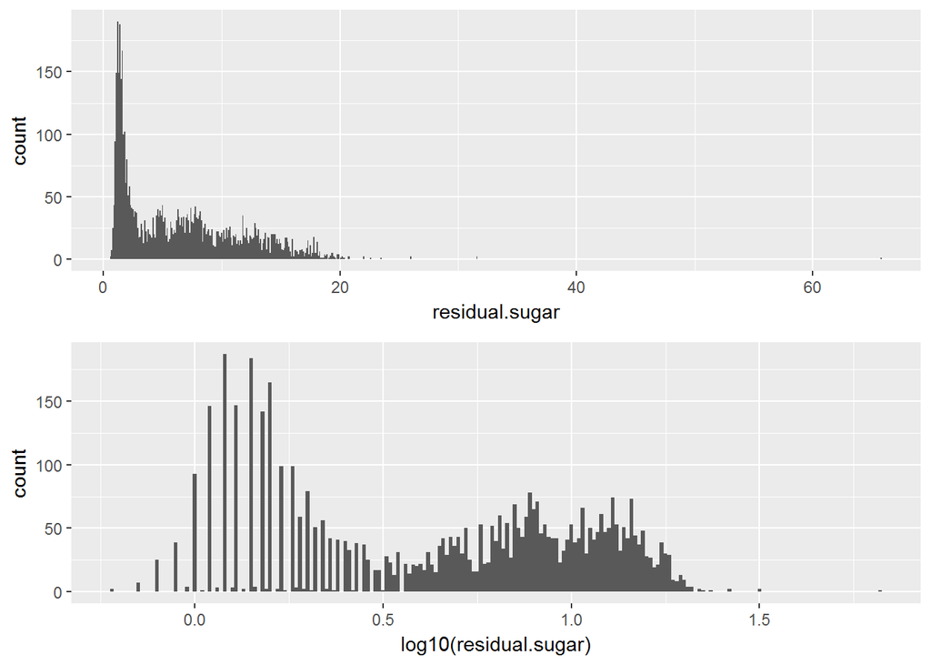

sugar是长尾分布，离群值很远，总体在0~20个单位之间。使用log10对数转化得到双峰分布。可以依此分为两组。

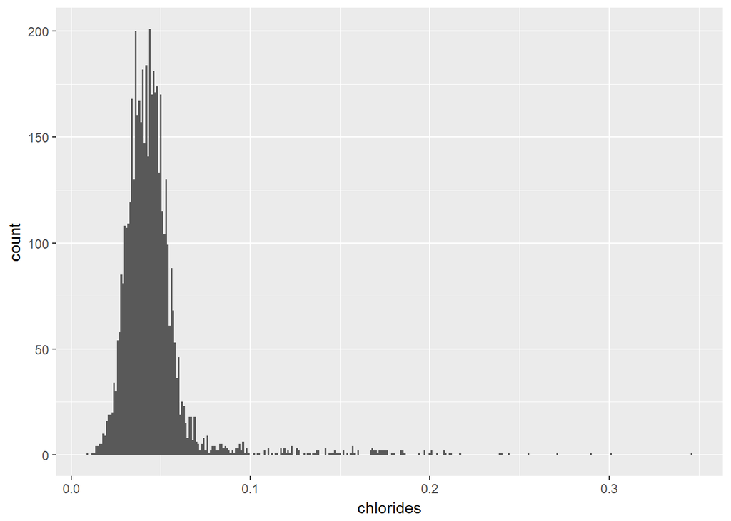

```
##    Min. 1st Qu.  Median    Mean 3rd Qu.    Max.
## 0.00900 0.03600 0.04300 0.04577 0.05000 0.34600
```

chlorides的含量与volatile.acidity和citric.acid在一个量级，大部分的含量在0.03~0.05之间。 下面考察硫化物的含量：

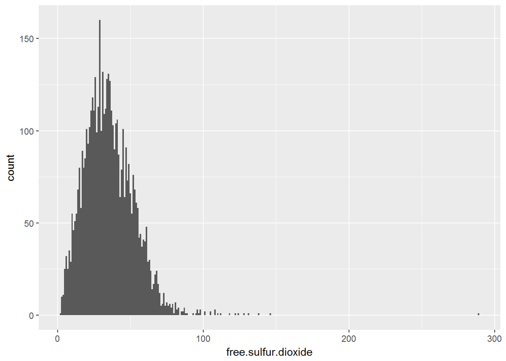

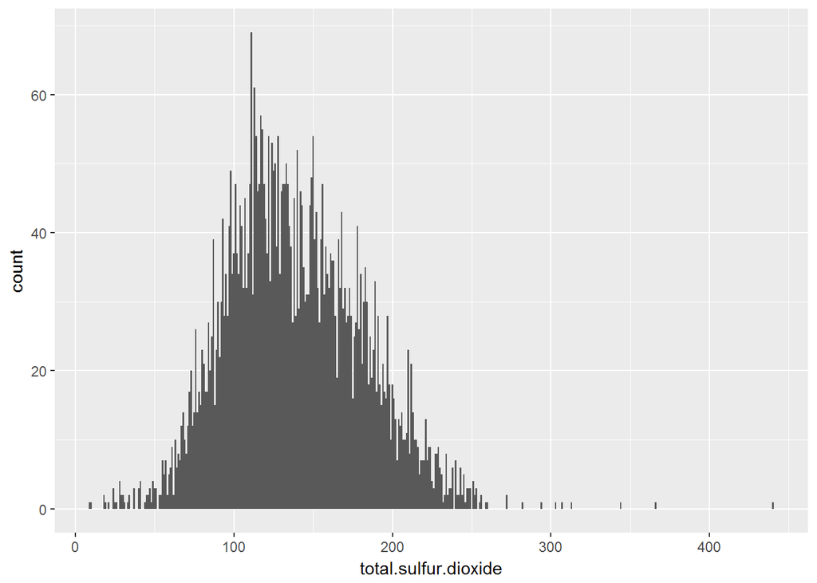

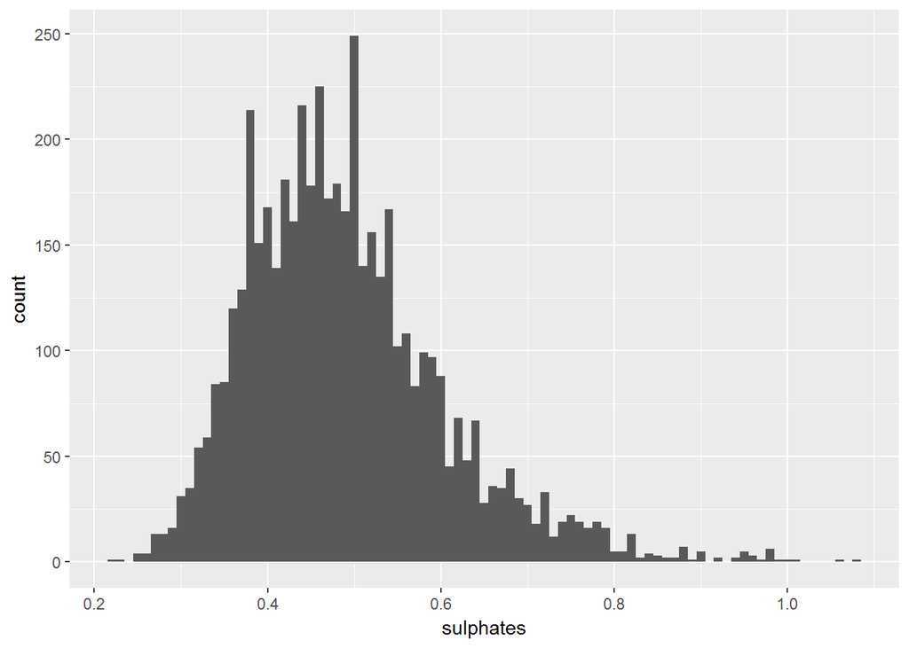

sulphates含量较低，sulfur.dioxide含量可观。 接下来是一些物化性质：

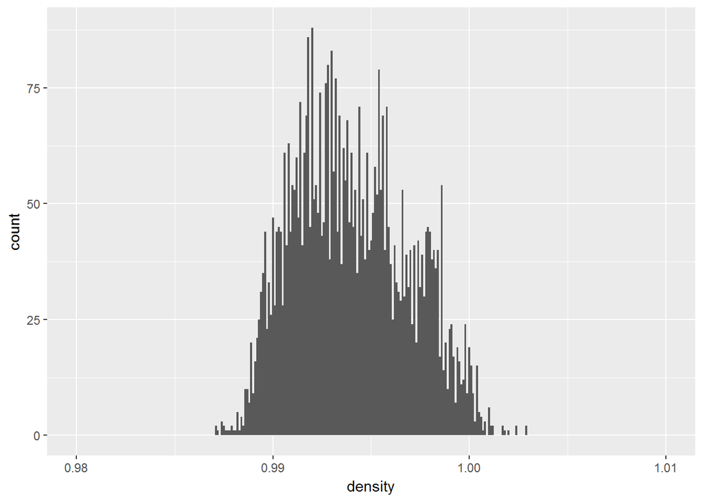

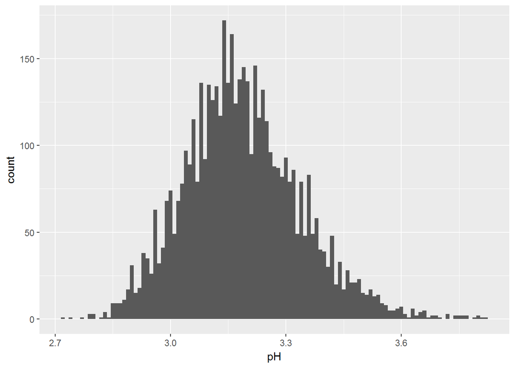

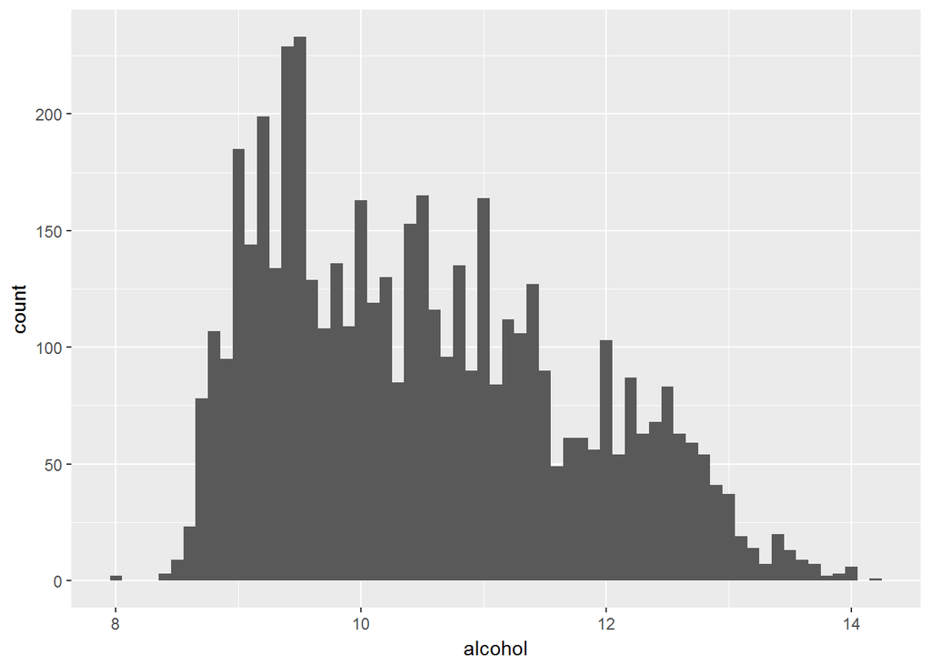

可见白葡萄酒酸度较高，酒精含量分布挺广，没有统一的标准。

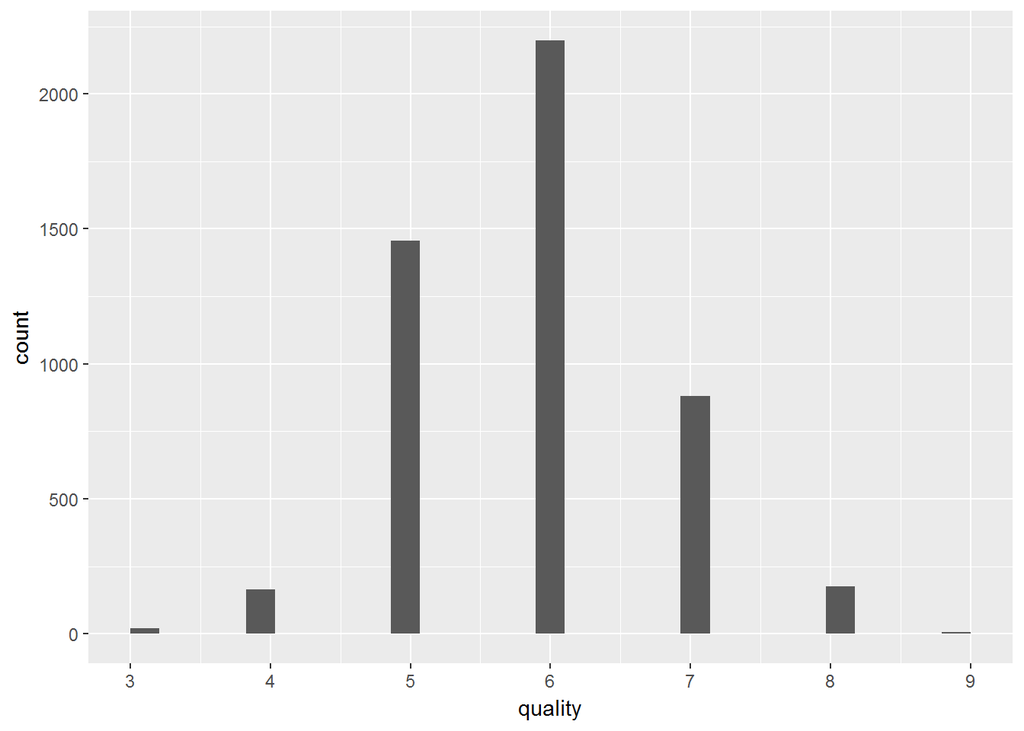

评分以中等水平为主。

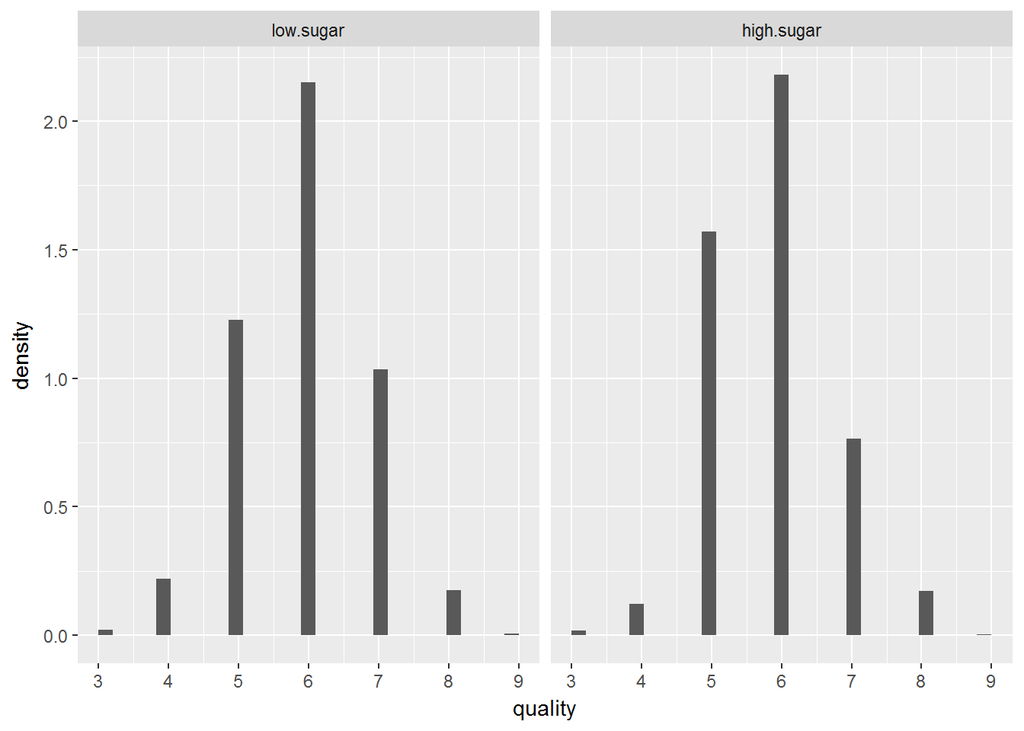

```
## wine$slevel: low.sugar
##    Min. 1st Qu.  Median    Mean 3rd Qu.    Max.
##   3.000   5.000   6.000   5.933   7.000   9.000
## --------------------------------------------------------
## wine$slevel: high.sugar
##    Min. 1st Qu.  Median    Mean 3rd Qu.    Max.
##   3.000   5.000   6.000   5.843   6.000   9.000
```

根据residual.sugar以3g/dm^3为界分组为少糖和多糖，作得分的频率直方图。可见，糖分较低的组的得分表现要比糖分较高的组略好。

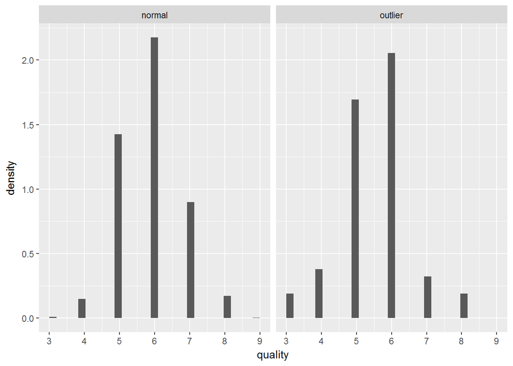

```
## wine$outlier: normal
##    Min. 1st Qu.  Median    Mean 3rd Qu.    Max.
##   3.000   5.000   6.000   5.898   6.000   9.000
## --------------------------------------------------------
## wine$outlier: outlier
##    Min. 1st Qu.  Median    Mean 3rd Qu.    Max.
##    3.00    5.00    6.00    5.52    6.00    8.00
```

将指标中具有明显离群值的归为outlier组。可见，普遍分布的得分表现更好。

# 单变量分析

### 你的数据集结构是什么？

其中有如下几类指标——  
酸类：fixed acidity，volatile acidity，citric acid  
糖类：residual sugar  
氯化物类：chlorides  
硫化物类：free sulfur dioxide，total sulfur dioxide，sulphates  
物化属性：density，pH，alcohol

大部分属性具有正态分布的特征。  
citric acid在0.5(g/dm^3)附近，residual sugar在1(g/dm^3)附近可看到集中趋势。  
氯化物及酸类有少量离群值。

### 你的数据集内感兴趣的主要特性有哪些？

探索两个方面：白葡萄酒中成分的含量或其组合是如何影响其评分的；某种成分过多或过少会导致怎样的评分结果。  
alcohol是酒类最主要的特征；residual.sugar跨度较大，且能划分出特征集中的‘少糖’组，可以作为分类依据。这两者都值得仔细探索。

### 你认为数据集内哪些其他特征可以帮助你探索兴趣特点？

其他指标都可以作为quality的自变量来探索。

### 根据数据集内已有变量，你是否创建了任何新变量？

创建了sugar和quality的因子变量slevel,qlevel.区分指标中是否有离群值的outlier.

### 在已经探究的特性中，是否存在任何异常分布？你是否对数据进行一些操作，如清洁、调整或改变数据的形式？如果是，你为什么会这样做？

# 双变量绘图选择

猜想口感可能取决于各口味的平衡度。创建新的变量sd，代表了acid sugar chlorides sulfur alcohol 五类物质的相对含量排名的标准差。  
加入三项物质间比例的指标：  
acid.bar.sugar=acid/sugar  
sugar.bar.chlorides=sugar/chlorides  
sugar.bar.alcohol=sugar/alcohol

```
##                      fixed.acidity volatile.acidity citric.acid
## fixed.acidity                1.000           -0.023      0.2892
## volatile.acidity            -0.023            1.000     -0.1495
## citric.acid                  0.289           -0.149      1.0000
## residual.sugar               0.089            0.064      0.0942
## chlorides                    0.023            0.071      0.1144
## free.sulfur.dioxide         -0.049           -0.097      0.0941
## total.sulfur.dioxide         0.091            0.089      0.1211
## density                      0.265            0.027      0.1495
## pH                          -0.426           -0.032     -0.1637
## sulphates                   -0.017           -0.036      0.0623
## alcohol                     -0.121            0.068     -0.0757
## quality                     -0.114           -0.195     -0.0092
## total.acid                   0.987            0.072      0.3941
## sd                           0.076            0.113      0.1046
## acid.bar.sugar               0.112           -0.105      0.0225
## sugar.bar.chlorides          0.074            0.065      0.0793
## sugar.bar.alcohol            0.094            0.046      0.1027
##                      residual.sugar chlorides free.sulfur.dioxide
## fixed.acidity                 0.089     0.023            -0.04940
## volatile.acidity              0.064     0.071            -0.09701
## citric.acid                   0.094     0.114             0.09408
## residual.sugar                1.000     0.089             0.29910
## chlorides                     0.089     1.000             0.10139
## free.sulfur.dioxide           0.299     0.101             1.00000
## total.sulfur.dioxide          0.401     0.199             0.61550
## density                       0.839     0.257             0.29421
## pH                           -0.194    -0.090            -0.00062
## sulphates                    -0.027     0.017             0.05922
## alcohol                      -0.451    -0.360            -0.25010
## quality                      -0.098    -0.210             0.00816
## total.acid                    0.105     0.046            -0.04513
## sd                            0.130     0.100            -0.02317
## acid.bar.sugar               -0.764    -0.047            -0.28881
## sugar.bar.chlorides           0.911    -0.160             0.24175
## sugar.bar.alcohol             0.990     0.119             0.31432
##                      total.sulfur.dioxide density       pH sulphates
## fixed.acidity                      0.0911   0.265 -0.42586  -0.01714
## volatile.acidity                   0.0893   0.027 -0.03192  -0.03573
## citric.acid                        0.1211   0.150 -0.16375   0.06233
```

[output cut: 35 more lines]

```
## citric.acid                       0.0793             0.103
## residual.sugar                    0.9114             0.990
## chlorides                        -0.1597             0.119
## free.sulfur.dioxide               0.2417             0.314
## total.sulfur.dioxide              0.2869             0.429
## density                           0.6723             0.872
## pH                               -0.1830            -0.201
## sulphates                        -0.0614            -0.018
## alcohol                          -0.2682            -0.537
## quality                          -0.0022            -0.135
## total.acid                        0.0881             0.108
## sd                                0.1414             0.154
## acid.bar.sugar                   -0.7434            -0.735
## sugar.bar.chlorides               1.0000             0.878
## sugar.bar.alcohol                 0.8775             1.000
```

剔除如下一些独立度不强、与其他量相关系数不大的指标： fixed.acidity,volatile.acidity,citric.acid,free.sulfur.dioxide,acid.bar.sugar,sugar.bar.chlorides. 作分别每两个量之间的散点图。

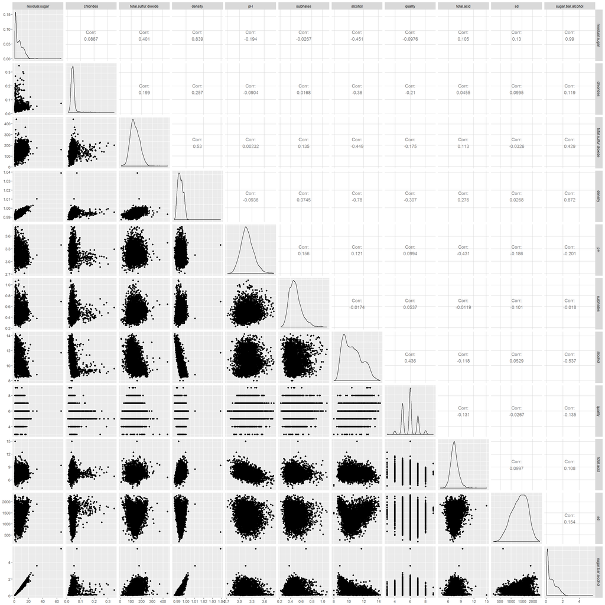

我们已经找到了可以重点进行双变量分析的对象。画出更直观的相关系数图。

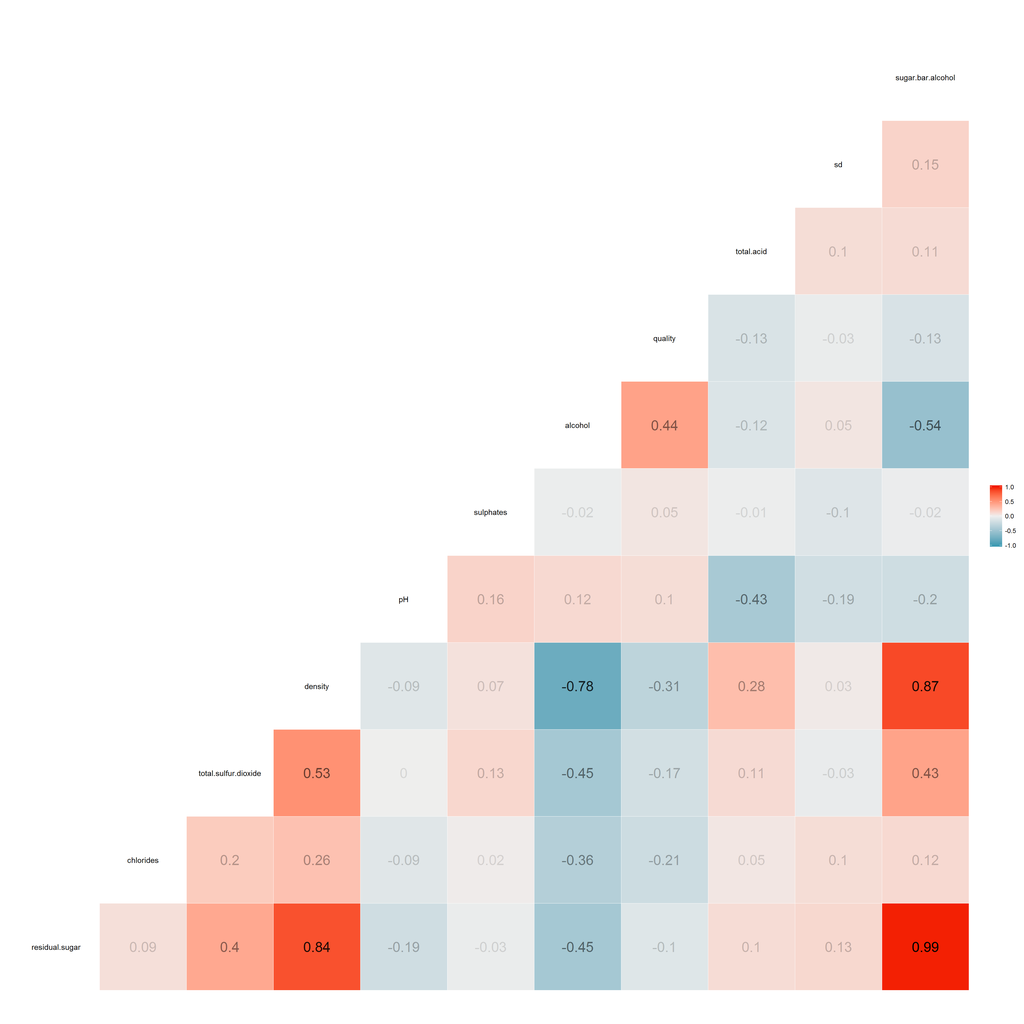

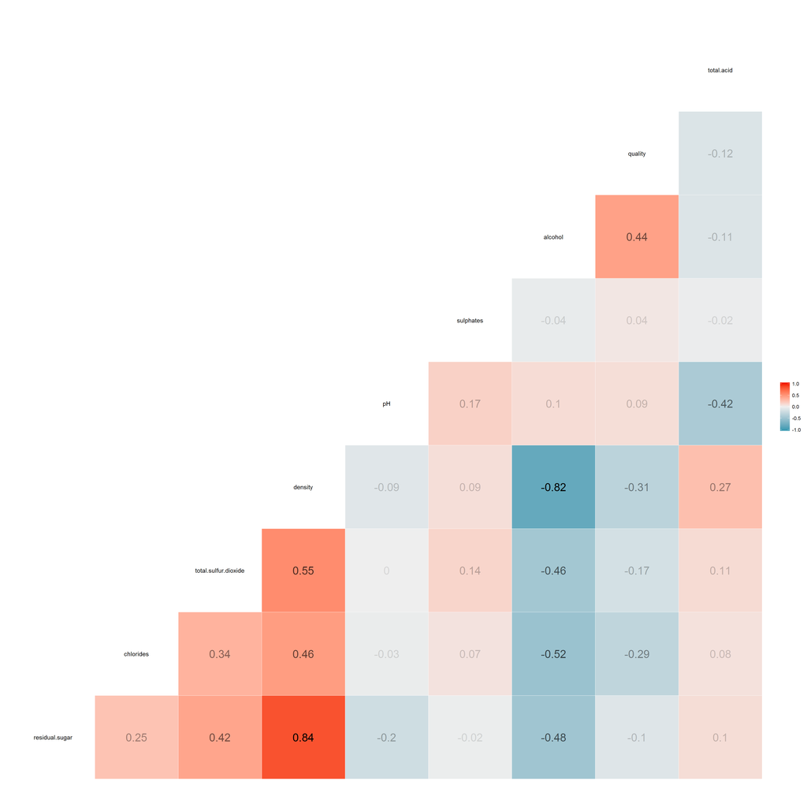

总结相关度较大的指标

关于density：

| density~ | 相关系数 |
| --- | --- |
| sugar.bar.alcohol | 0.87 |
| residual.sugar | 0.84 |
| total.sulfur.dioxide | 0.53 |
| alcohol | -0.783 |
| quality | -0.31 |

关于alcohol：

| quality~ | 相关系数 |
| --- | --- |
| alcohol | 0.44 |
| density | -0.31 |

其他：

| 变量1 | 变量2 | 相关系数 |
| --- | --- | --- |
| alcohol | residual.sugar | -0.45 |
| alcohol | total.sulfur.dioxide | -0.45 |
| alcohol | chlorides | -0.36 |
| fixed.acidity | pH | -0.43 |
| residual.sugar | total.sulfur.dioxide | 0.40 |
| volatile.acidity | quality | -0.19 |

我们最关系的quality与alcohol的正相关系数达到了0.44，画出箱线图看每个评级的酒精范围。

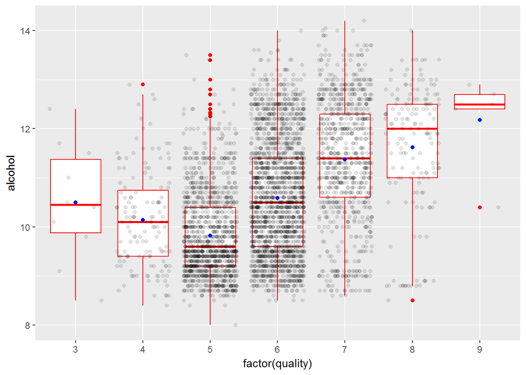

sugar有多糖少糖之分，也想看一下他们的评分表现。

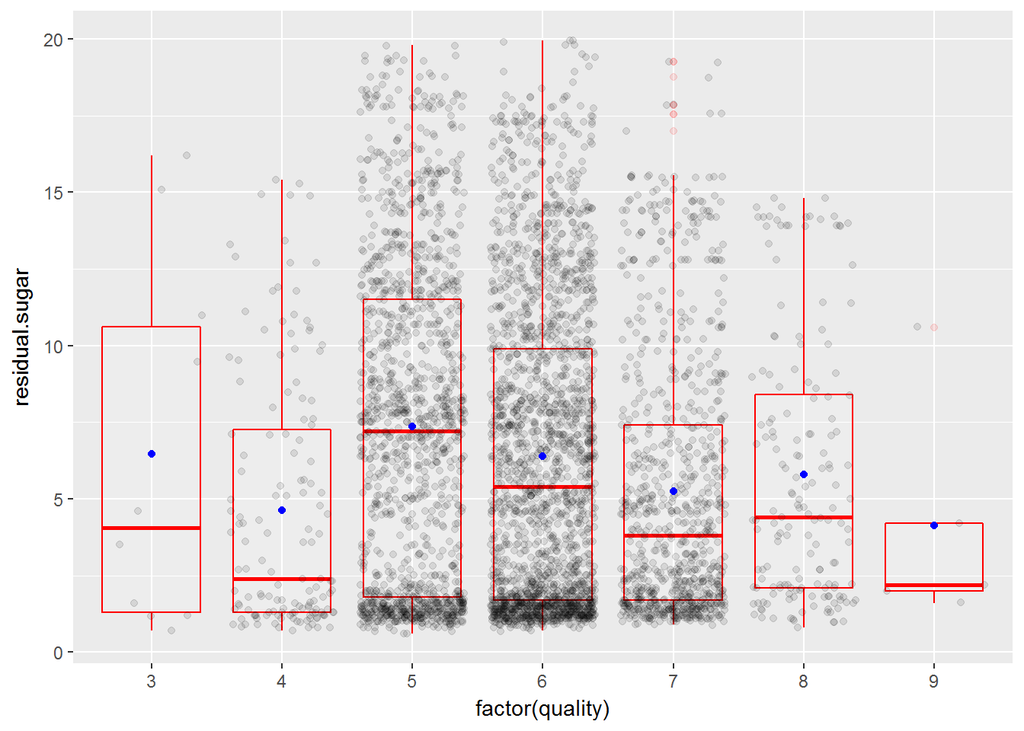

```
## <ScaleContinuousPosition>
##  Range:
##  Limits:    0 --   20
```

total.acid,chlorides与quality负相关。

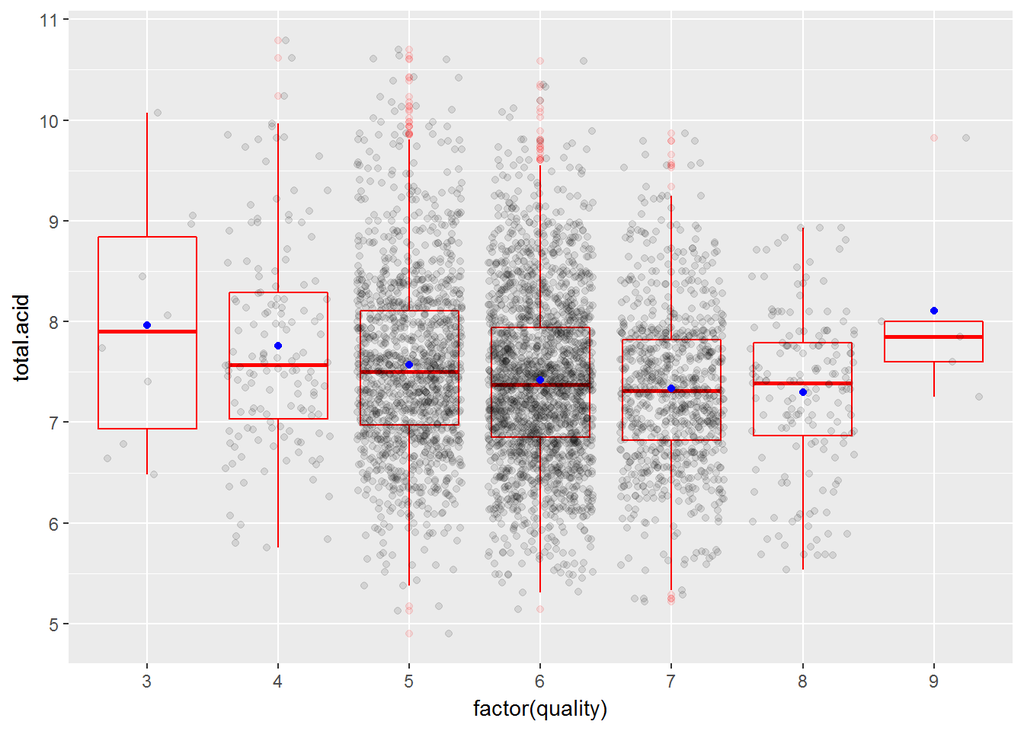

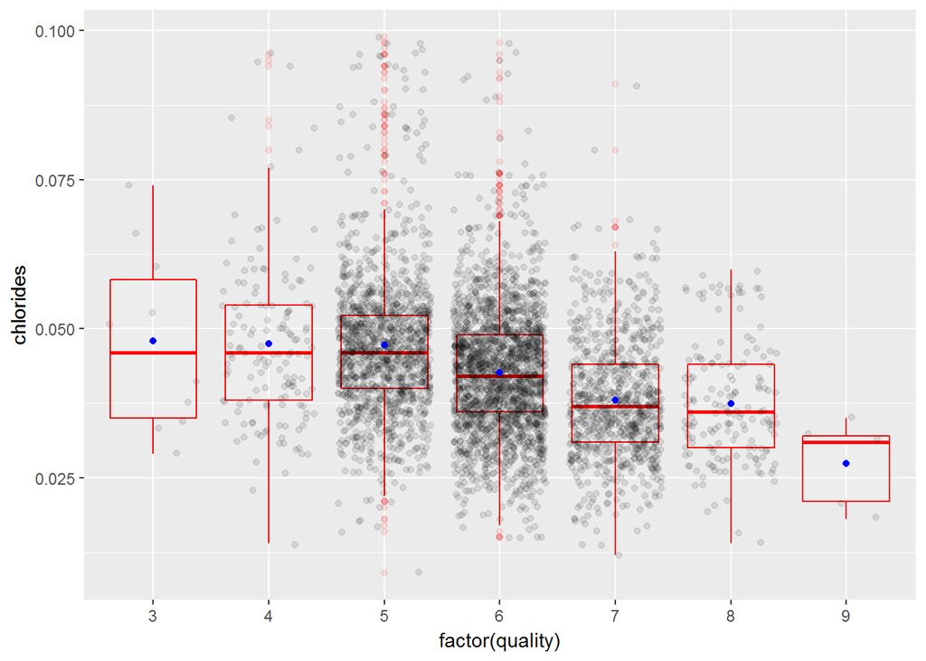

sugar与density正相关。

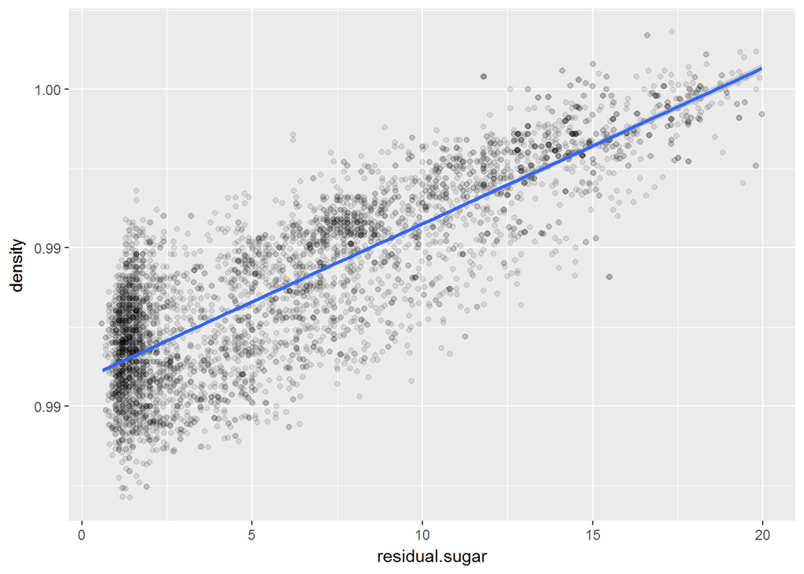

pH的最大影响因素：

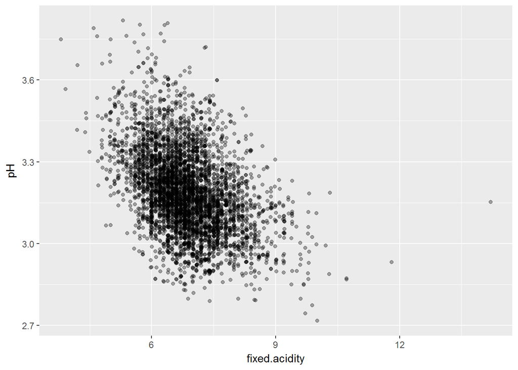

# 双变量分析

### 探讨你在这部分探究中观察到的一些关系。这些感兴趣的特性与数据集内其他特性有什么区别？

density与可溶于水的物质都正相关，糖是有机物，相关系数更大。与alcohol负相关，因为酒精比水轻。  
pH值受fixed.acidity影响较大，而与volatile.acidity无关。后者会对quality造成轻微的负面影响。

### 你是否观察到主要特性与其他特性之间的有趣关系？

quality与alcohol正相关，与density负相关。高评分的酒大多有高alcohol低sugar的特点。

### 你发现最强的关系是什么？

# 多变量绘图选择

我们来看一下在不同糖分的基底上，alcohol和clorides成分对评分的影响。

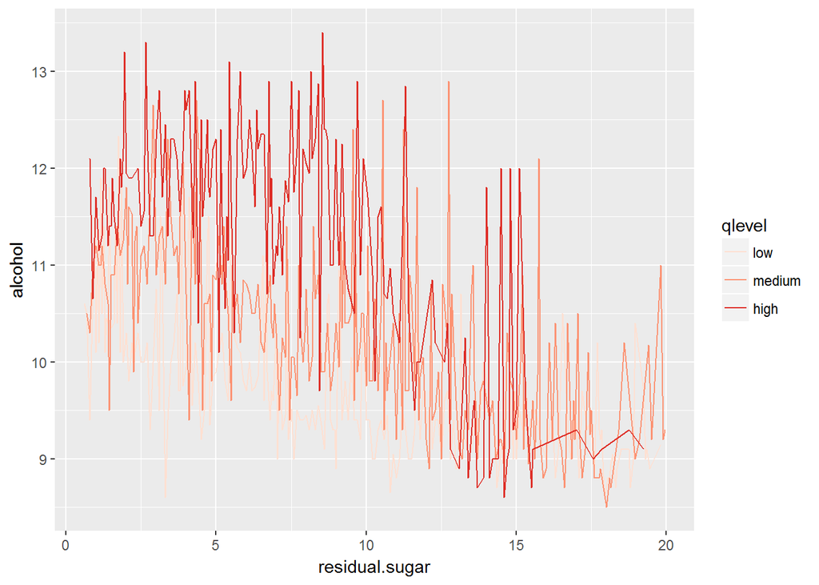

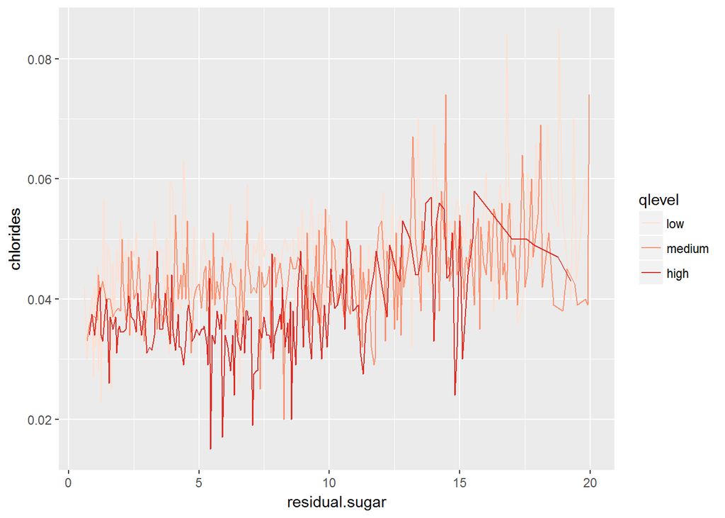

```
##
## Call:
## lm(formula = quality ~ alcohol + chlorides + residual.sugar +
##     total.sulfur.dioxide + fixed.acidity, data = subset(wine,
##     outlier == "normal"))
##
## Residuals:
##    Min     1Q Median     3Q    Max
## -3.359 -0.551 -0.003  0.450  3.128
##
## Coefficients:
##                       Estimate Std. Error t value Pr(>|t|)
## (Intercept)           2.877956   0.202909   14.18  < 2e-16 ***
## alcohol               0.331944   0.012337   26.91  < 2e-16 ***
## chlorides            -6.971245   1.175513   -5.93  3.2e-09 ***
## residual.sugar        0.024647   0.002719    9.07  < 2e-16 ***
## total.sulfur.dioxide  0.000531   0.000322    1.65      0.1 .
## fixed.acidity        -0.059459   0.014072   -4.23  2.4e-05 ***
## ---
## Signif. codes:  0 '***' 0.001 '**' 0.01 '*' 0.05 '.' 0.1 ' ' 1
##
## Residual standard error: 0.77 on 4638 degrees of freedom
## Multiple R-squared:  0.22,   Adjusted R-squared:  0.219
## F-statistic:  261 on 5 and 4638 DF,  p-value: <2e-16
```

# 多变量分析

### 探讨你在这部分探究中观察到的一些关系。通过观察感兴趣的特性，是否存在相互促进的特性？

sugar小于10个单位时，alcohol越高，得到的评分也越高。大于10个单位时，评分总体下降且差异性变小. sugar小于10个单位时，chlorides越小，得到的评分也越高。

### 这些特性之间是否存在有趣或惊人的联系呢？

residual.sugar=10g/dm^3是上述两个变化趋势的共同的分水岭。这可能意味着，糖分较少时，其他因素能发挥作用，而当糖分过多时，就掩盖了其他味觉。

### 选项：你是否创建过数据集的任何模型？讨论你模型的优缺点。

建立了quality对于alcohol+chlorides+residual.sugar+total.sulfur.dioxide+fixed.acidity的线性模型。Multiple R-squared为 0.22，只能解释22%的变化，效果不好。白葡萄酒的质量判定比较复杂.

# 定稿图与总结

### 绘图一

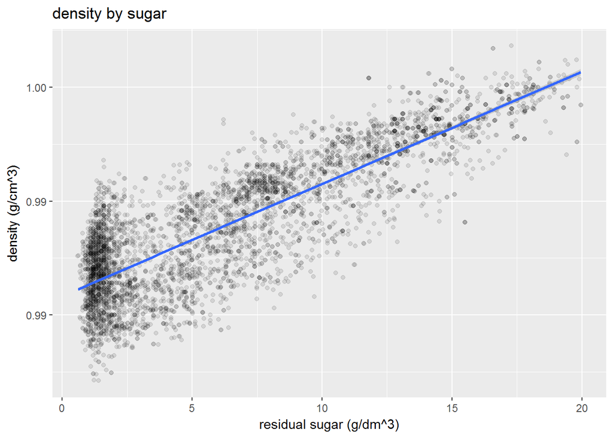

### 绘图二

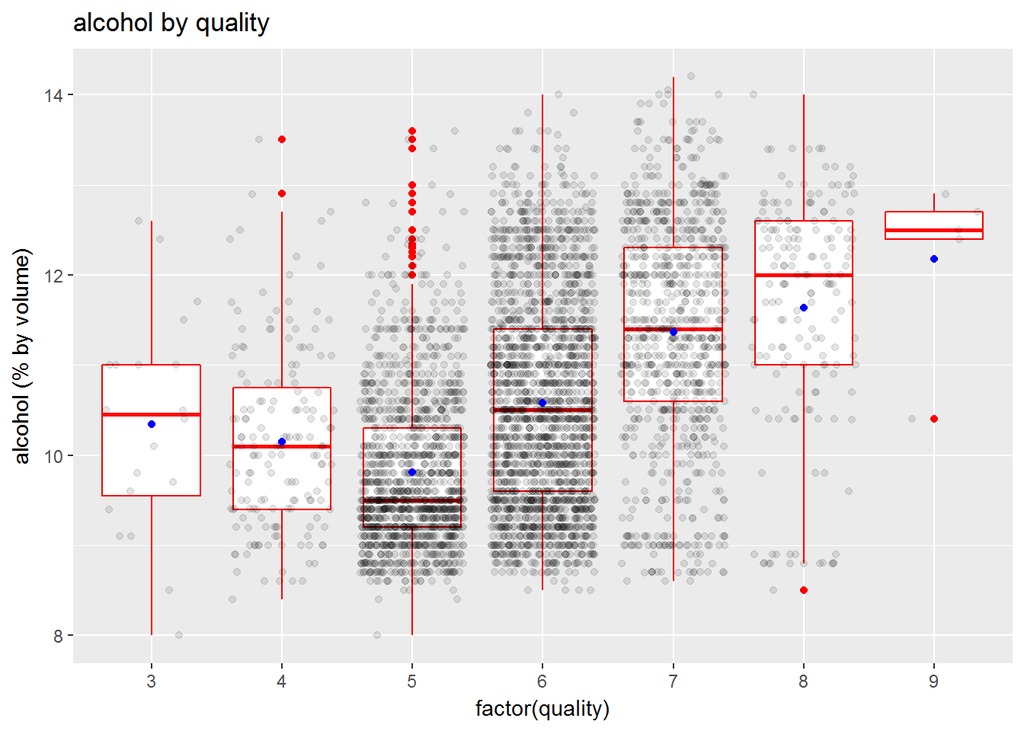

### 描述二

对于中等以上品质的酒来说，酒精度越高，评分越好。

### 绘图三

[figure not shown]

### 描述三

仅考虑中位数： sugar小于10个单位时，总体alcohol越高，得到的评分也越高。sugar小于10个单位时，chlorides越小，得到的评分也越高。 residual.sugar=10g/dm^3是上述两个变化趋势的共同的分水岭。这可能意味着，糖分较少时，其他因素能发挥作用，而当糖分过多时，就掩盖了其他味觉。

# 反思

在白葡萄酒数据中，先看了各个指标各自的分布，为了分类观察，取出满足正态分布的连续值的离群值作为一组。对有两个峰的糖分，则能分为两组。评分分为三组。  
然后探索了两个变量间的关系。原本期待的不同成分间的平衡度，与评分相关度很低。选择的三组物质间的比例相关度也不大。酒精和密度这对负相关量与评分比较有关。然后选取了部分指标传递给ggpair函数，方便查看。  
探索多变量时，按照alcohol by sugar，chlorides by sugar并按照评分来分类，惊喜地看出了一些结果。尝试生成一个线性模型，效果不理想。  
本项目的未来工作，可以考虑尝试更多的变量组合，寻找特定的能较好预测评分的区间。另外，不同评委的给分区间即严格程度是不同的，应使用按分布标准化后的评分。